# Exploración de datos sobre vino.

Jorge González

21.08.2023

## Introducción

En el siguiente informe exploraremos datos sobre reseñas de vinos publicadas en la revista [WineEnthusiast](http://www.winemag.com/?s=&drink_type=wine).

### Origen de los datos.

Se trata de un conjunto de datos traducidos y extraídos como resumen de las casi 130.000 reseñas de vinos con variedad, ubicación, bodega, precio y descripción existentes en [Kaggle](https://www.kaggle.com/zynicide/wine-reviews). Los datos se extrajeron de WineEnthusiast durante la semana del 15 de junio de 2017.

## Exploración de los datos

### Variables

Tenemos 10 variables que se listan a continuación:

```
##  [1] "pais"          "nombre"        "puntos"        "precio"
##  [5] "provincia"     "region_1"      "region_2"      "variedad"
##  [9] "vina"          "titulo_resena"
```

La muestra cuenta con 129971 observaciones. Estas observaciones corresponden a 708 variedades o cepas de vino de 44 paises diferentes.

### Países con más vinos reseñados.

Los 10 países con más vinos reseñados son:

| País | Cantidad reseñas |
| --- | --- |
| Estados Unidos | 54504 |
| Francia | 22093 |
| Italia | 19540 |
| España | 6645 |
| Portugal | 5691 |
| Chile | 4472 |
| Argentina | 3800 |
| Austria | 3345 |
| Australia | 2329 |
| Alemania | 2165 |

### Países con vinos más caros.

El ránking de los vinos más caros en promedio lo lideran:

| País | Precio promedio |
| --- | --- |
| Suiza | 85,29 |
| Inglaterra | 51,68 |
| Alemania | 42,26 |
| Francia | 41,14 |
| Hungría | 40,65 |
| Italia | 39,66 |
| Estados Unidos | 36,57 |
| Canadá | 35,71 |
| Australia | 35,44 |
| Israel | 31,77 |

El rango de precios oscila entre los 4 y los 3300 euros.  
El promedio general de precios es de 35,36 euros.  
Su desvío estándar 41,02.

### Países con mejores puntuaciones.

Los países con los mejores puntajes acumulados son:

| País | Puntaje promedio |
| --- | --- |
| Inglaterra | 91,58 |
| India | 90,22 |
| Austria | 90,10 |
| Alemania | 89,85 |
| Canadá | 89,37 |
| Hungría | 89,19 |
| China | 89,00 |
| Francia | 88,85 |
| Luxemburgo | 88,67 |
| Australia | 88,58 |

El peor puntaje es de 80 puntos y el mejor de 100.  
El promedio general de puntos es de 88 puntos.  
Su desvío estándar 3.

### Cepas más valoradas según puntaje.

Las 10 cepas con mejor puntaje son:

| Variedad | Puntaje promedio |
| --- | --- |
| Gelber Traminer | 95,00 |
| Terrantez | 95,00 |
| Tinta del Pais | 95,00 |
| Bual | 94,14 |
| Riesling-Chardonnay | 94,00 |
| Sercial | 94,00 |
| Blauburgunder | 93,00 |
| Garnacha-Cariñena | 93,00 |
| Ramisco | 93,00 |
| Muscadelle | 92,50 |
| Rosenmuskateller | 92,50 |
| Roviello | 92,50 |
| Sirica | 92,50 |

## Hipótesis

1. Asumiendo que la mayor calificación en las reseñas refieren a una mayor “calidad” del vino reseñado ¿cuáles son los países con mejor relación precio-calidad?
2. ¿Se disparan los precios si las calificaciones están por encima de los 95 puntos?
3. ¿Cuál es la relación para los vinos argentinos?

## Conclusiones

1. Luego de relacionar las variables “puntos” y “precio” (puntos/precio) y de calcular la mediana de la relación, graficamos:

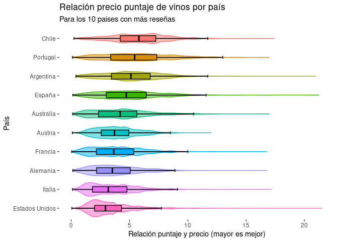

Según vemos en el gráfico los vinos chilenos, portugueses y argentinos son los que cuentan con la mejor relación precio calidad para este grupo de países (top 10 de cantidad de reseñas).

2. En cuanto al aumento de precios para los vinos mejor calificados (más de 95 puntos):

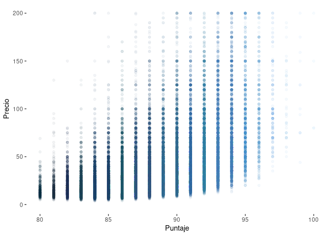

Si bien existe un aumento de precios, no se ve que se disparen para los vinos que cuentan con calificaciones por encima de los 95 puntos.

3. Gráfica de la relación precio/calidad para los vinos argentinos.

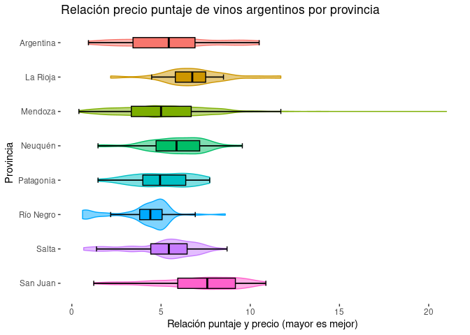